# Cleaning the Data

This is a record of Philip Stallworth’s contributions to the data cleaning process. It should be noted that these contributions are largely computational and could not have been performed without the expertise of Haley Tilt.

# Getting the File in Working Order

```r
africaFull <- read.csv("edh.csv", header = TRUE, sep = "\t")
head(africaFull)
```

```
##     HD.no. work.status province...Italic.region         modern.country
## 1 HD000139 provisional     Africa Proconsularis Libyan Arab Jamahiriya
## 2 HD000370 provisional     Africa Proconsularis                Tunisia
## 3 HD000373 provisional     Africa Proconsularis                Tunisia
## 4 HD000376 provisional     Africa Proconsularis                Tunisia
## 5 HD000379 provisional     Africa Proconsularis                Tunisia
## 6 HD000382 provisional     Africa Proconsularis                Tunisia
##   ancient.find.spot modern.find.spot find.spot..village..street..etc..
## 1          Sabratha         Şabrātah         Forum, sekundär verwendet
## 2       Vallis, bei     Mejez El Bab
## 3            Gunela      Hr. Goungla
## 4             Aradi        Bou Arada          südl. Bordj de Bou Arada
## 5            Sucubi     Hr. Brerrita
## 6                    Hr. Ali Sagatte
##   Chronological.data
```

[output cut: 27 more lines]

I want to isolate the inscriptions, which are in column 10. Right now they are coded as a factor, but this is bad because each time I query the factor vector, it reports back both the entry and a list of all the levels. This is really slow, plus coding this variable as a factor makes no sense, because inscriptions are not inherently categorical. What I will do is convert the 10th column into a character vector and work with those.

```r
africaFull[,10] <- as.character(africaFull[,10])
africaFull[12, 10]
```

```
## [1] "Calpurnia Q(uinti) f(ilia) / Gemina p(ia) v(ixit) a(nnos) L(?)X // L(ucius) Calpurnius S[---]"
```

# Find the Epitaphs

Next, I constructed a function that looks for words in a character string, while ignoring certain characters. Essentially, it “categorizes” inputs by determining whether or not the input contains one of the trigger words. In the package this function is called binaryCat. It references a helper function called categorize which takes a vector of strings as input and outputs whether or not each string contains a vector of specified string.

```r
findEpitaphs <- binaryCat(africaFull[,10], c("infans", "innocens", "puer", "puella", "relinquit", "quiebit", "perit", "reccessit", "recessit", "quiesco", "periit", "decessit",
            "vixit", "vicxit", "vixsit", "bixit", "visisti", "vixi", "occisus", "occisa", "positus", "depositus", "deposita",
            "funus", "hic situs est", "situs est", "in pace", "in pacae", "memoriae", "memoriam", "parentibus", "diis manibus",
            "dis manibus"))
nrow(africaFull)
```

```
## [1] 3826
```

```r
epitaphs <- africaFull[findEpitaphs == T, ]
nrow(epitaphs)
```

```
## [1] 1203
```

We managed to get rid of 2623 observations through this method. The words were chosen because expert opinion claims they are sufficient to find all epitaphs.

# Finding age categories

First, I built a function to modify the inscriptions so only characters would be included. This made finding words and ages easier, because the original enscriptions contained a number of archaeological notations to indicate assumptions, misspellings, and missing information. This portion is a little repetitive. You can see that in my earlier function I create the substitutions within each function, rather than requiring a clean vector a priori.

```r
subs <- c("(", ")", "[", "]", "{", "}", "?", "/", "!", "#")

modifiedInscriptions <- rep(NA, nrow(epitaphs))
for(i in 1:nrow(epitaphs)){
  modifiedInscriptions[i] <- epitaphs[i, 10]
  for(j in 1:length(subs)){
    past <- modifiedInscriptions[i]
    modifiedInscriptions[i] <- sub(subs[j], "", past, fixed = TRUE)
    while(modifiedInscriptions[i] != past){
      past <- modifiedInscriptions[i]
      modifiedInscriptions[i] <- sub(subs[j], "", past, fixed = TRUE)
    }
  }
}
```

Next I found the age categories. This first involved creating a function which finds a word then looks directly after it for a roman numeral (called findRomanNumeral). We then convert that roman numeral into a regular number and put it into a vector. We need to do this for years, months, days, and hours columns. Fortunately, the same function should work for each.

```r
findRomanNumeral(modifiedInscriptions[1], "annos")
```

```
## [1] 18
```

```r
findRomanNumeral(modifiedInscriptions[2], "annis")
```

```
## [1] 66
```

```r
findRomanNumeral(modifiedInscriptions[3], "annis")
```

```
## [1] 60
```

Yay, so that is done. Now fill out the age categories for each inscription. I use a function called findRomanNumeralMulti to general findRomanNumeral to multiple enscriptions and multiple age indicators. The key words are annis and annos.

```r
years <- findRomanNumeralMulti(modifiedInscriptions, c("annos", "annis"))
months <- findRomanNumeralMulti(modifiedInscriptions, c("menses", "mensibus"))
days <- findRomanNumeralMulti(modifiedInscriptions, c("dies", "diebus"))
hours <- findRomanNumeralMulti(modifiedInscriptions, c("horas", "oras", "horis"))

length(years[!is.na(years)])
```

```
## [1] 754
```

```r
length(months[!is.na(months)])
```

```
## [1] 163
```

```r
length(days[!is.na(days)])
```

```
## [1] 96
```

```r
length(hours[!is.na(hours)])
```

```
## [1] 14
```

```r
epitaphs <- data.frame(epitaphs, years, months, days, hours)
```

For posterity we have 754 years recorded, 163 months recorded, 96 days recorded, and 14 hours recorded. This is an over-estimate because many of these times refer to military service.

# Visualizations Part 1

Here are some nice histograms. We are seeing how much information is regarding for individuals of different ages.

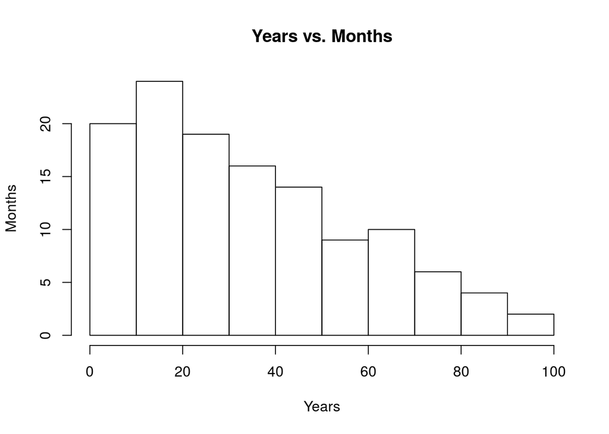

```r
hist(epitaphs[!is.na(epitaphs[,13]), 12],
     ylab = "Months",
     xlab = "Years",
     main = "Years vs. Months")
```

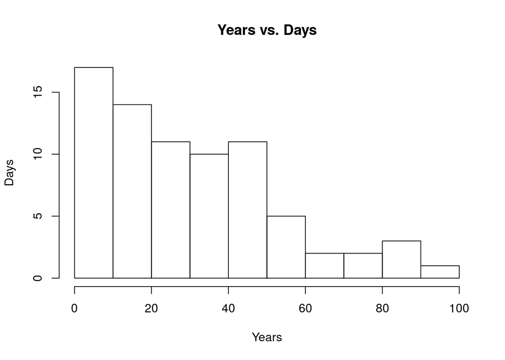

```r
hist(epitaphs[!is.na(epitaphs[,14]), 12],
     ylab = "Days",
     xlab = "Years",
     main = "Years vs. Days")
```

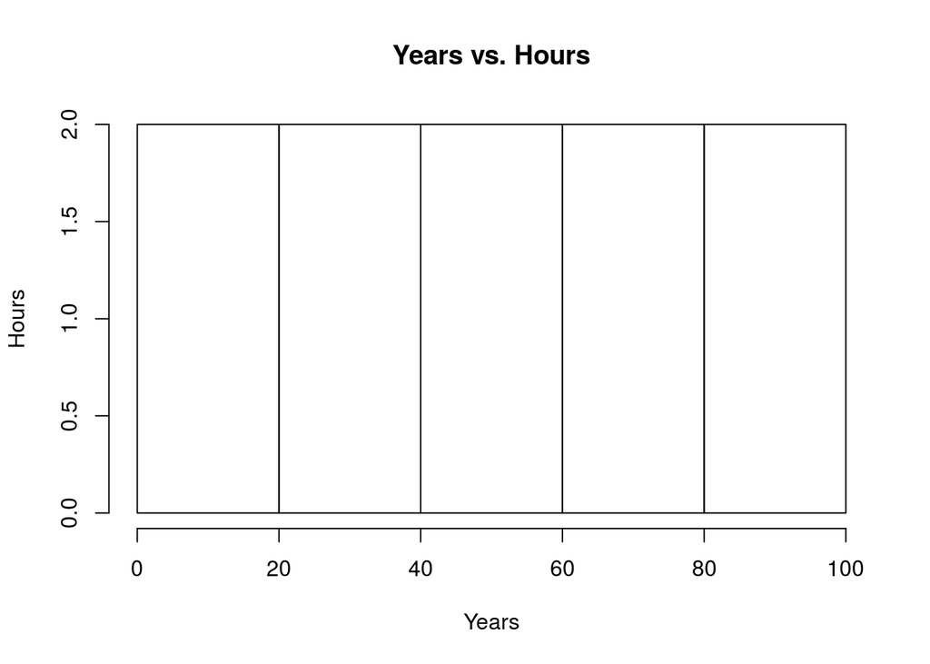

```r
hist(epitaphs[!is.na(epitaphs[,15]), 12],
     ylab = "Hours",
     xlab = "Years",
     main = "Years vs. Hours")
```

Next we look at word prevalence by age.

```r
piusList <- epitaphs[grep("pius", modifiedInscriptions),]
nrow(piusList)
```

```
## [1] 182
```

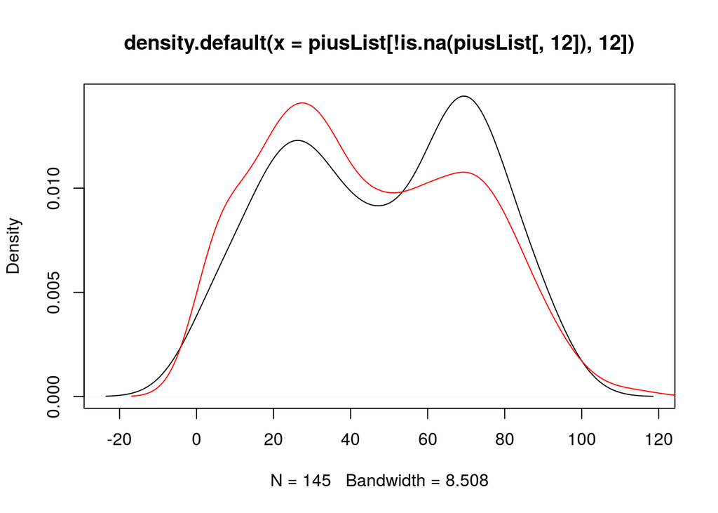

```r
plot(density(piusList[!is.na(piusList[,12]), 12]))
lines(density(epitaphs[!is.na(epitaphs[,12]), 12]), col = "red")
```

# Include some age markers

```r
hasYear <- binaryCat(modifiedInscriptions, c("annos", "annis") )
hasMonth <- binaryCat(modifiedInscriptions, c("menses", "mensibus"))
hasDay <- binaryCat(modifiedInscriptions, c("dies", "diebus"))
hasHour <- binaryCat(modifiedInscriptions, c("horas", "horis", "oras"))

missingNumber <- rep(FALSE, nrow(epitaphs))

for(i in 1:length(missingNumber)){
  if((hasYear[i] == TRUE && is.na(epitaphs$years[i])) || (hasMonth[i] == TRUE && is.na(epitaphs$months[i])) || (hasDay[i] == TRUE && is.na(epitaphs$days[i])) || (hasHour[i] == TRUE && is.na(epitaphs$hours[i]))){
    missingNumber[i] <- TRUE
  }
}
```

Next I want to make a column which indicates whether an inscriptions covers many individuals. She said to check for multiple instantiations of the term vixit.

```r
vixitAlts <- c("vixit", "vicxit", "vixsit", "bixit", "visisti", "vixi")
multiFam <- rep(F, nrow(epitaphs))
for(i in 1:length(multiFam)){
  j <- 1
  while(j <= length(vixitAlts) && multiFam[i] != TRUE){
    loc <- regexpr(vixitAlts[j], modifiedInscriptions[i])
    if(loc[1] != -1){
        k <- 1
        while(k <= length(vixitAlts) && multiFam[i] != TRUE){
          multiFam[i] <- grepl(vixitAlts[k], substr(modifiedInscriptions[i], loc[1] + slot(loc, "match.length"), 100000000))
          k <- k + 1
        }
    }
    j <- j + 1
    }
}
```